# Project: Identify Customer Segments

## 1st Principle Component

### 8.4. PLZ8_ANTG3

Number of 6-10 family houses in the PLZ8 region

- -1: unknown
- 0: no 6-10 family homes
- 1: lower share of 6-10 family homes
- 2: average share of 6-10 family homes
- 3: high share of 6-10 family homes

### 4.3. CAMEO_INTL_2015_Wealth

German CAMEO: Wealth, mapped to international code

- -1: unknown
- 1: Wealthy Households
- 2: Prosperous Households
- 3: Comfortable Households
- 4: Less Affluent Households
- 5: Poorer Households

### 1.16. LP_STATUS_GROB_1.0

Social status, rough scale

- 0: Not low-income earners
- 1: low-income earners

### 8.2. PLZ8_ANTG1

Number of 1-2 family houses in the PLZ8 region

- -1: unknown
- 0: no 1-2 family homes
- 1: lower share of 1-2 family homes
- 2: average share of 1-2 family homes
- 3: high share of 1-2 family homes
- 4: very high share of 1-2 family homes

### 5.1. KBA05_ANTG1

Number of 1-2 family houses in the microcell

- -1: unknown
- 0: no 1-2 family homes
- 1: lower share of 1-2 family homes
- 2: average share of 1-2 family homes
- 3: high share of 1-2 family homes
- 4: very high share of 1-2 family homes

### 7.3. MOBI_REGIO

Movement patterns

- 1: very high movement
- 2: high movement
- 3: middle movement
- 4: low movement
- 5: very low movement
- 6: none

```python
# What kinds of people are part of a cluster that is underrepresented in the
# customer data compared to the general population?
extracted_data_14 = scaler.inverse_transform(np.dot(customers_PCA, pca_final.components_))[np.where(customers_pred==14)]
extracted_data_14 = pd.DataFrame(extracted_data_14, columns=azidas_feat_scaled.columns)
extracted_data_10 = scaler.inverse_transform(np.dot(customers_PCA, pca_final.components_))[np.where(customers_pred==10)]
extracted_data_10 = pd.DataFrame(extracted_data_10, columns=azidas_feat_scaled.columns)
```

```
0    3.0
Name: PLZ8_ANTG3, dtype: float64
```

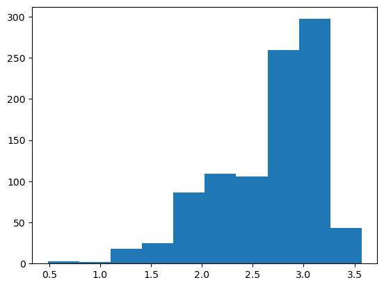

```
0    5.0
Name: CAMEO_INTL_2015_WEALTH, dtype: float64
```

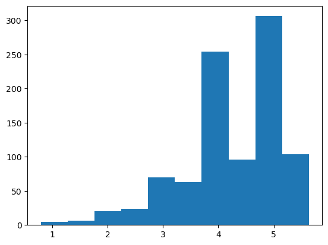

```
0    1.0
Name: LP_STATUS_GROB_1.0, dtype: float64
```

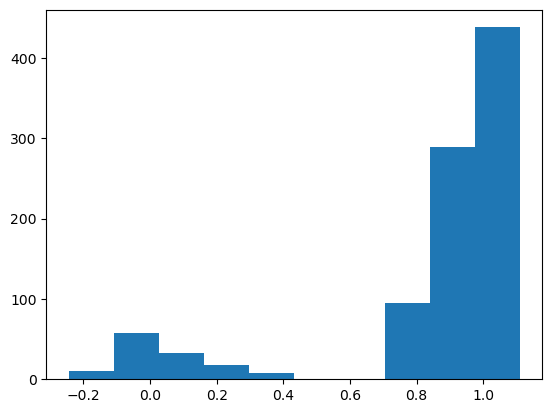

```
0    1.0
Name: PLZ8_ANTG1, dtype: float64
```

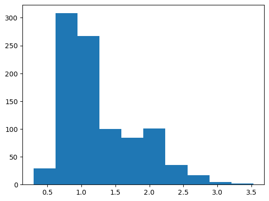

```
0   -0.0
Name: KBA05_ANTG1, dtype: float64
```

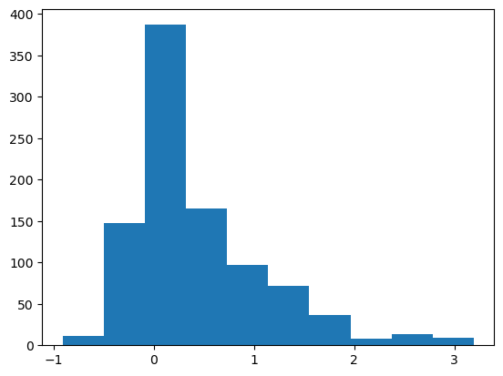

```
0    1.0
Name: MOBI_REGIO, dtype: float64
```

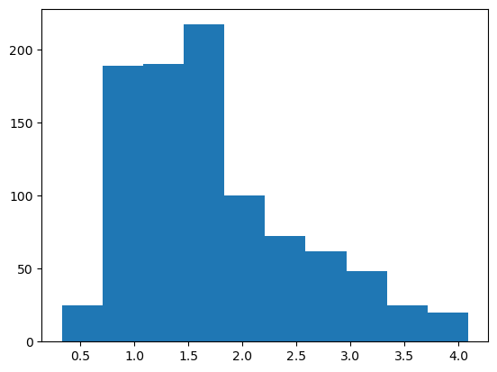

```python
for feat in weight_map(azidas_feat_scaled, pca_final, 0,3).index:
    print(extracted_data_14[feat].round().mode())
    plt.hist(extracted_data_14[feat]);
    plt.show()
```

```
0    3.0
Name: PLZ8_ANTG3, dtype: float64
```

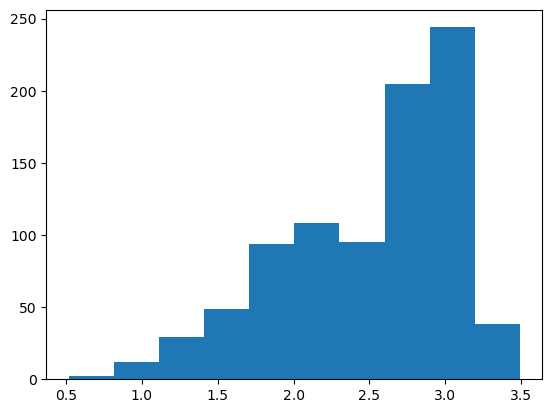

```
0    4.0
Name: CAMEO_INTL_2015_WEALTH, dtype: float64
```

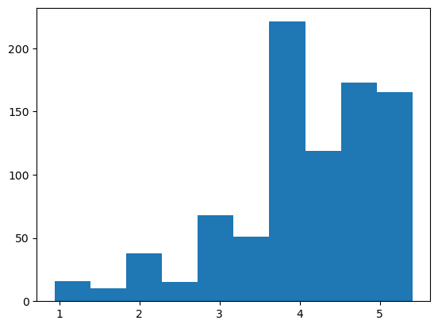

```
0    1.0
Name: LP_STATUS_GROB_1.0, dtype: float64
```

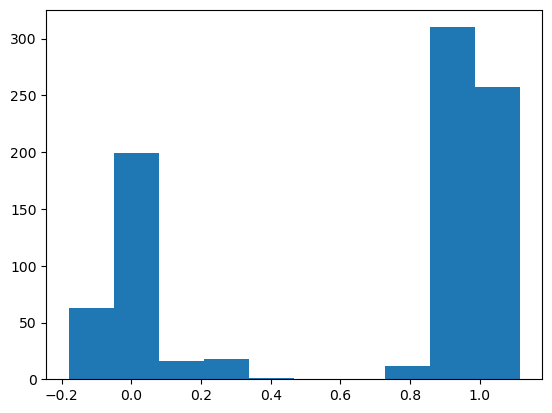

```
0    1.0
Name: PLZ8_ANTG1, dtype: float64
```

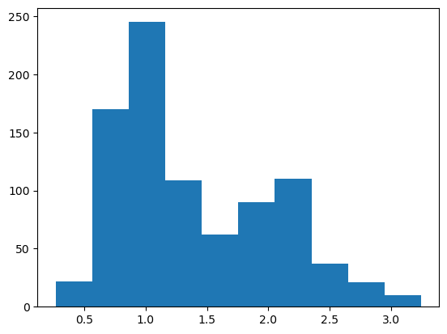

```
0   -0.0
Name: KBA05_ANTG1, dtype: float64
```

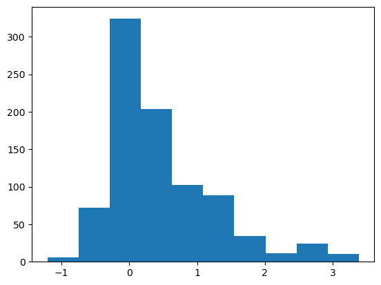

```
0    1.0
Name: MOBI_REGIO, dtype: float64
```

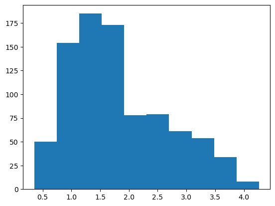

```python
for feat in weight_map(azidas_feat_scaled, pca_final, 0,3).index:
    print(extracted_data_10[feat].round().mode())
    plt.hist(extracted_data_10[feat]);
    plt.show()
```

## 2nd Principle Component

### 1.2. ALTERSKATEGORIE_GROB

Estimated age based on given name analysis

- -1: unknown (missing)
- 0: unknown (cannot be determined)
- 1: < 30 years old
- 2: 30 - 45 years old
- 3: 46 - 60 years old
- 4: > 60 years old
- 9: uniformly distributed

### 1.5. FINANZ_VORSORGER,

Financial typology, for each dimension. Dimension translations- VORSORGER: be prepared

- -1: unknown
- 1: very high
- 2: high
- 3: average
- 4: low
- 5: very low

### 1.20. SEMIO_ERL

Personality typology, for each dimension. ERL: event-oriented

- -1: unknown
- 1: highest affinity
- 2: very high affinity
- 3: high affinity
- 4: average affinity
- 5: low affinity
- 6: very low affinity
- 7: lowest affinity
- 9: unknown

### 1.20. SEMIO_REL

Personality typology, for each dimension. REL: religious

- -1: unknown
- 1: highest affinity
- 2: very high affinity
- 3: high affinity
- 4: average affinity
- 5: low affinity
- 6: very low affinity
- 7: lowest affinity
- 9: unknown

### 1.5. FINANZ_UNAUFFAELLIGER,

Financial typology, for each dimension, - UNAUFFAELLIGER: inconspicuous

- -1: unknown
- 1: very high
- 2: high
- 3: average
- 4: low
- 5: very low

### 1.5. FINANZ_SPARER,

Financial typology, for each dimension, - SPARER: money-saver

- -1: unknown
- 1: very high
- 2: high
- 3: average
- 4: low
- 5: very low

```
0    2.0
Name: ALTERSKATEGORIE_GROB, dtype: float64
```

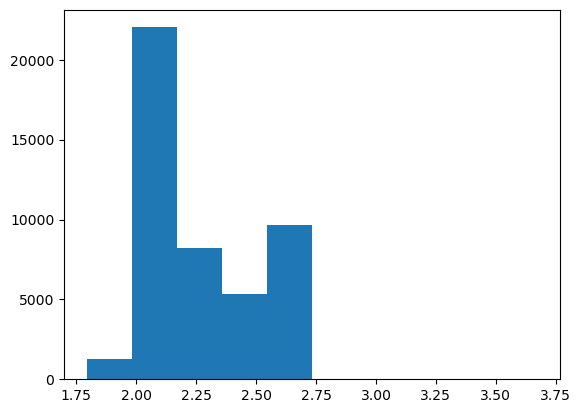

```
0    3.0
Name: FINANZ_VORSORGER, dtype: float64
```

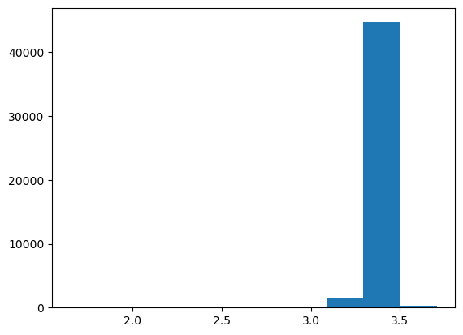

```
0    3.0
Name: SEMIO_ERL, dtype: float64
```

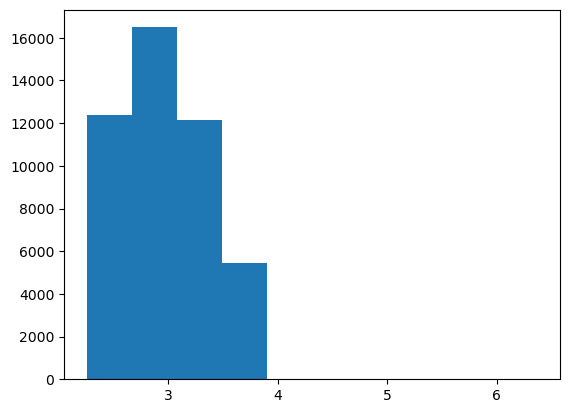

```
0    7.0
Name: SEMIO_REL, dtype: float64
```

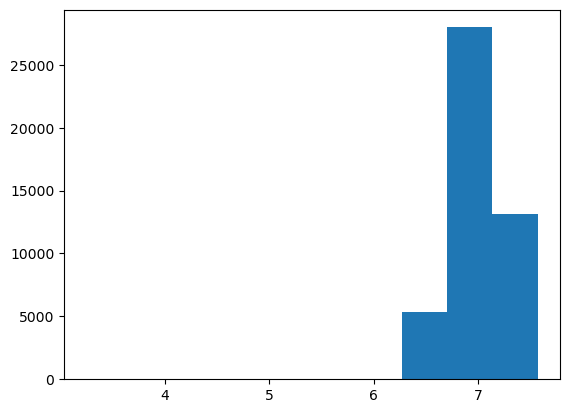

```
0    5.0
Name: FINANZ_UNAUFFAELLIGER, dtype: float64
```

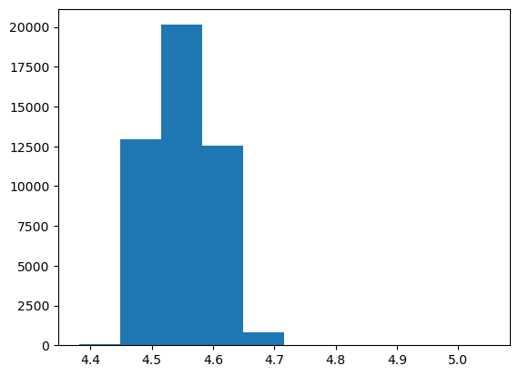

```
0    3.0
Name: FINANZ_SPARER, dtype: float64
```

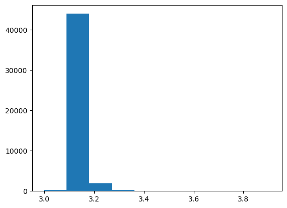

```python
for feat in weight_map(azidas_feat_scaled, pca_final, 1,3).index:
    print(extracted_data_6[feat].round().mode())
    plt.hist(extracted_data_6[feat]);
    plt.show()
```

```
0    4.0
Name: ALTERSKATEGORIE_GROB, dtype: float64
```

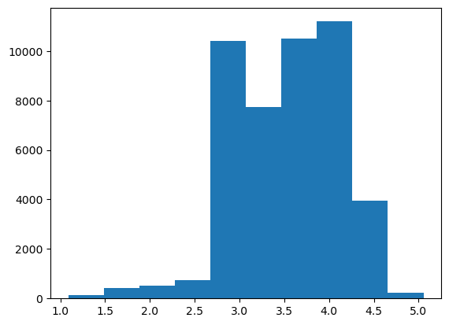

```
0    5.0
Name: FINANZ_VORSORGER, dtype: float64
```

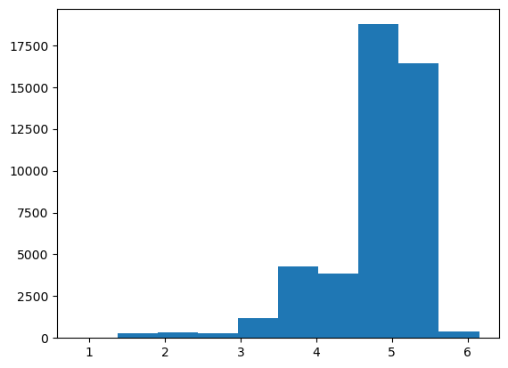

```
0    4.0
Name: SEMIO_ERL, dtype: float64
```

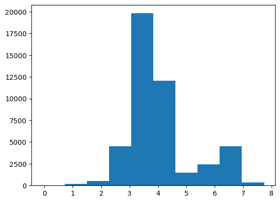

```
0    4.0
Name: SEMIO_REL, dtype: float64
```

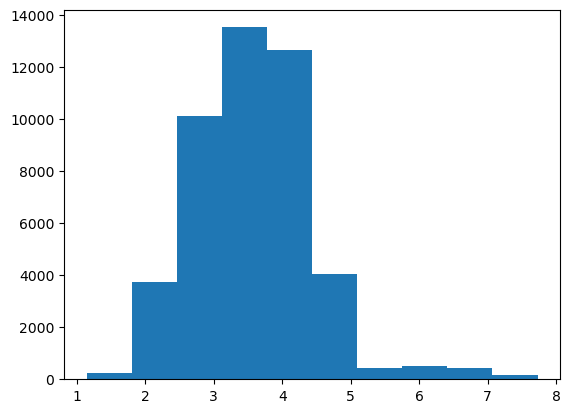

```
0    2.0
Name: FINANZ_UNAUFFAELLIGER, dtype: float64
```

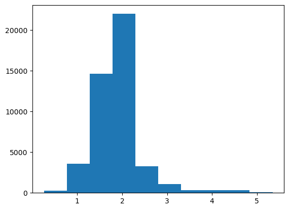

```
0    1.0
Name: FINANZ_SPARER, dtype: float64
```

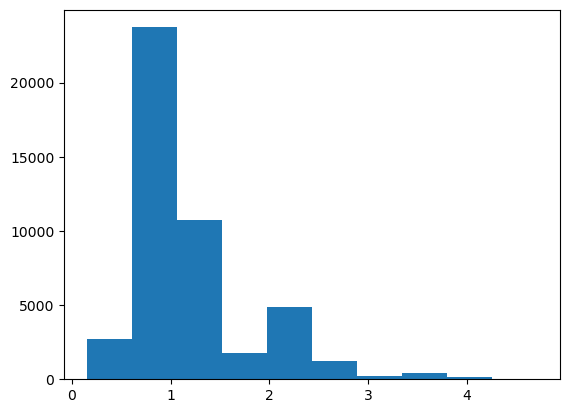

```python
for feat in weight_map(azidas_feat_scaled, pca_final, 1,3).index:
    print(extracted_data_12[feat].round().mode())
    plt.hist(extracted_data_12[feat]);
    plt.show()
```

```
0    1.0
Name: ALTERSKATEGORIE_GROB, dtype: float64
```

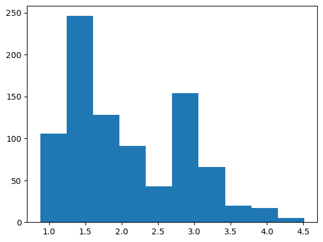

```
0    2.0
Name: FINANZ_VORSORGER, dtype: float64
```

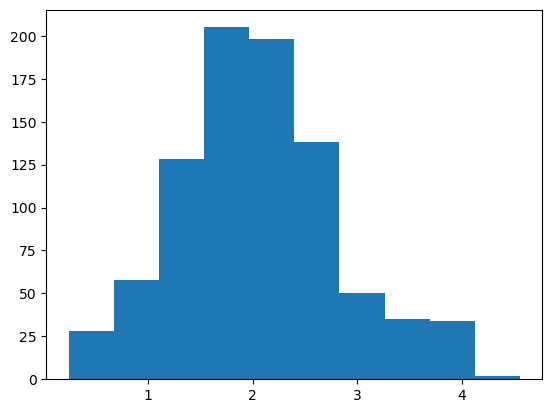

```
0    2.0
Name: SEMIO_ERL, dtype: float64
```

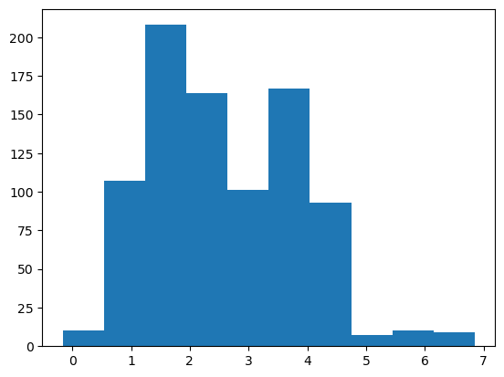

```
0    7.0
Name: SEMIO_REL, dtype: float64
```

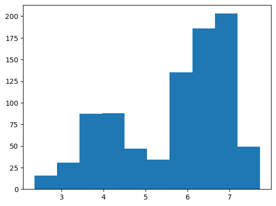

```
0    4.0
Name: FINANZ_UNAUFFAELLIGER, dtype: float64
```

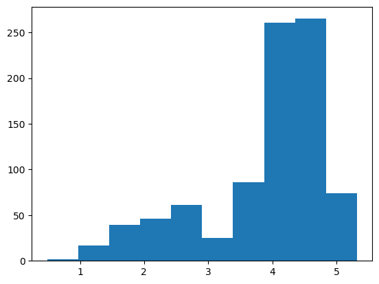

```
0    4.0
Name: FINANZ_SPARER, dtype: float64
```

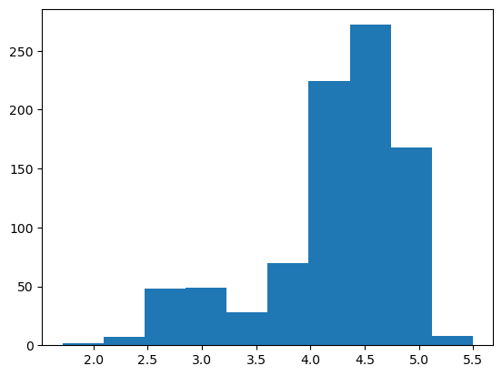

```python
for feat in weight_map(azidas_feat_scaled, pca_final, 1,3).index:
    print(extracted_data_10[feat].round().mode())
    plt.hist(extracted_data_10[feat]);
    plt.show()
```

```
0    2.0
Name: ALTERSKATEGORIE_GROB, dtype: float64
```

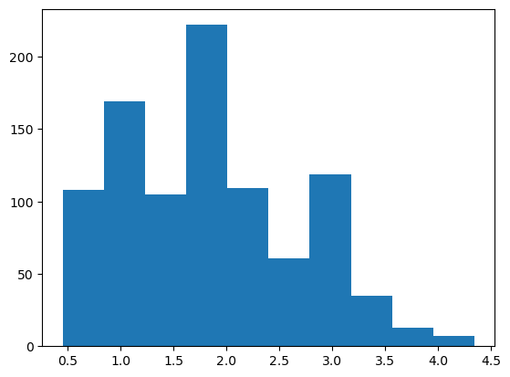

```
0    2.0
Name: FINANZ_VORSORGER, dtype: float64
```

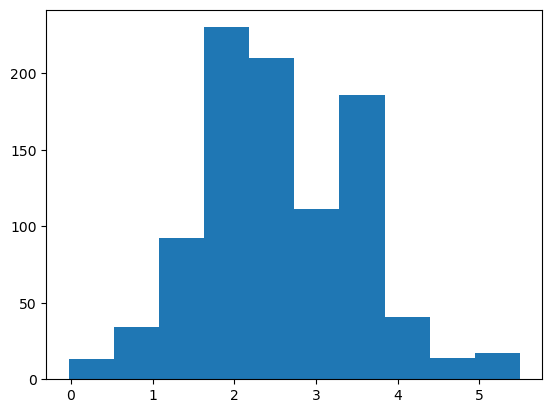

```
0    5.0
Name: SEMIO_ERL, dtype: float64
```

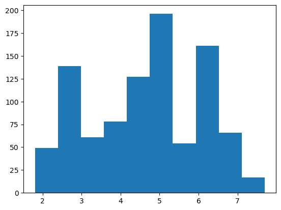

```
0    6.0
Name: SEMIO_REL, dtype: float64
```

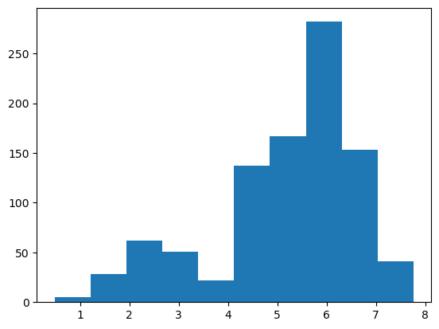

```
0    4.0
Name: FINANZ_UNAUFFAELLIGER, dtype: float64
```

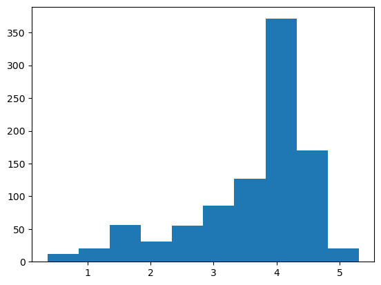

```
0    4.0
Name: FINANZ_SPARER, dtype: float64
```

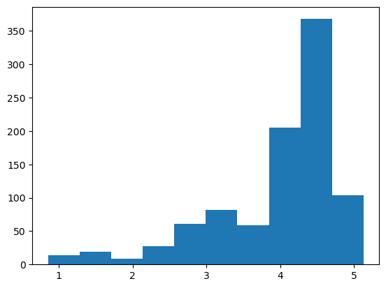

```python
for feat in weight_map(azidas_feat_scaled, pca_final, 1,3).index:
    print(extracted_data_14[feat].round().mode())
    plt.hist(extracted_data_14[feat]);
    plt.show()
```

## Discussion 3.3: Compare Customer Data to Demographics Data

### Relatively popular with the mail-order company

#### The 7th (ID 6) and 13th (ID 12) clusters are popular and overrepresented.

#### - From 1st Principal component

We notice that they are wealthy households (CAMEO_INTL_2015_WEALTH = 1 or 2) and dont have low income (LP_STATUS_GROB_1.0 = 0). Another thing to notice is that they have high share of 1-2 family houses and low share of 6-10 family houses in the PLZ8 region (PLZ8_ANTG3 score is low and PLZ8_ANTG1/KBA05_ANTG1 score is high). Also they show low movement patterns (MOBI_REGIO = 4)

#### - From 2nd Principal component

7th cluster is for 30-45 years, they have average financial preparedness and are not religious(SEMIO_REL = 7). The 13th cluster is for 45 and above. They are having less financial preparedness and are moderately religious. They have less financial knowledge and are good money savers.

### Relatively unpopular with the company

#### The 15th (ID 14) and 11th (ID 10) clusters are unpopular and underrepresented.

#### - From 1st Principal component

We notice that they are poor households (CAMEO_INTL_2015_WEALTH = 4 or 5) and have low income (LP_STATUS_GROB_1.0 = 1). Another thing to notice is that they have low or no share of 1-2 family houses and high share of 6-10 family houses in the PLZ8 region(PLZ8_ANTG3 score is high and PLZ8_ANTG1/KBA05_ANTG1 score is low, 1/0). Also they show high movement patterns (MOBI_REGIO = 1)

#### - From 2nd Principal component

The 15th cluster is not conclusive for 2nd principal compnent, they are not religious. They have above average financial understanding and they are not money savers. The 11th cluster is of young people under 30, so they are generally a bad target. They have financial preparedness and are not religious. They also have high financial understanding and they are not money savers.

> Congratulations on making it this far in the project! Before you finish, make sure to check through the entire notebook from top to bottom to make sure that your analysis follows a logical flow and all of your findings are documented in **Discussion** cells. Once you've checked over all of your work, you should export the notebook as an HTML document to submit for evaluation. You can do this from the menu, navigating to **File -> Download as -> HTML (.html)**. You will submit both that document and this notebook for your project submission.